# Assignment05

Margaret Connor

2/26/2019

**What is the rule learning method?**

The rule learning method or one rule method is a classification method similar to the decision tree and Naive Bayer’s methods. The Rule learning method generates one rule for each factor and uses the rule with the smallest error to classify unlabled data. The lower the error means a higher contribution to the predictability of the model. In relation to the decision tree this method is similar to a 1-level decision tree and like Naive Bater’s it relies on the ues of a frequency table to find the smallest error in the rules.

**Try to explain how this method work step by step.**

We will use rule learning to predict a home’s value (low, medium, high) based on the following data.

Source of data example (Molnar, Christoph. “Interpretable Machine Learning.” Christoph Molnar, 22 Feb. 2019, christophm.github.io/interpretable-ml-book/rules.html.)

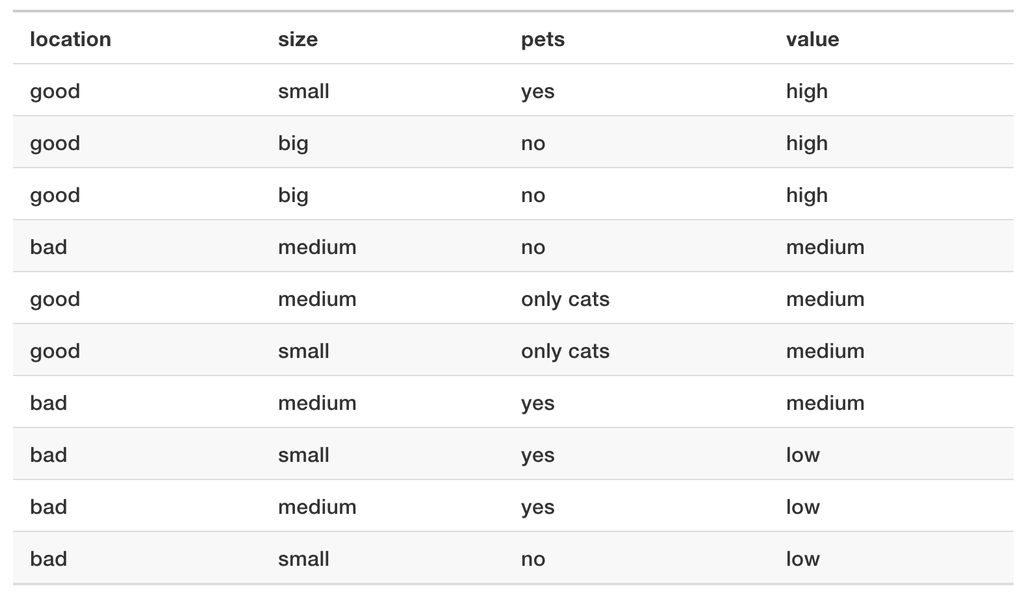

**STEP 1** The method begins by count how often a factor value appears with the target lable. Creating a frequency table to help illistrate how often a factor value appears with the target label.

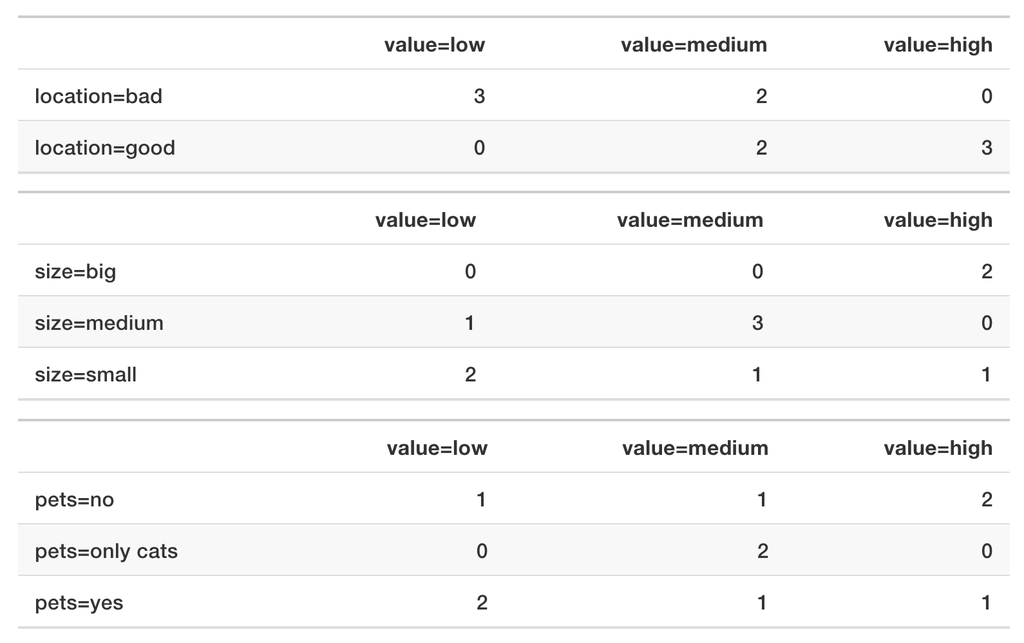

**STEP 2** Next we make a rule for each factor that can be applied to the observed lables. We do this by going row for row and identifying if else statements for each factor value

**Location**

- IF location = bad THEN value = low
- IF location = good THEN value = high

**Size**

- IF size = big THEN value = high
- IF size = medium THEN value = medium
- IF size = small THEN value = low

**Pets**

- IF pets = no THEN value = high
- IF pets = only cats THEN value = medium
- IF pets = yes THEN value = low

**STEP 3** After the labels rules have been identified the error of each factor’s rules is calculated.

Location Error rate = 4/10

Size Error rate = 3/10

Pets Error rate = 4/10

**STEP 4** Finally the rule with the lowest error rate is selected as the one rule and used to predict unlabled data. In this exampel we have a predicted accuracy rate of approzimatly 70%, and classifies all examples based on the one rule.

**How to use this classification method using R:** Provide the R package and R function

```r
#install.packages("OneR");
library(OneR)
```

**How to use this classification method using R:** Try to apply this method using any of the available data from previous labs to train and test the model

Import the data from Lab 5 credit.csv

```r
credit <-read.csv('/Users/margaretconnor/NetBeansProjects/Rdata/credit.csv', stringsAsFactors = TRUE)
str(credit)
```

```
## 'data.frame':    1000 obs. of  17 variables:
##  $ checking_balance    : Factor w/ 4 levels "< 0 DM","> 200 DM",..: 1 3 4 1 1 4 4 3 4 3 ...
##  $ months_loan_duration: int  6 48 12 42 24 36 24 36 12 30 ...
##  $ credit_history      : Factor w/ 5 levels "critical","good",..: 1 2 1 2 4 2 2 2 2 1 ...
##  $ purpose             : Factor w/ 6 levels "business","car",..: 5 5 4 5 2 4 5 2 5 2 ...
##  $ amount              : int  1169 5951 2096 7882 4870 9055 2835 6948 3059 5234 ...
##  $ savings_balance     : Factor w/ 5 levels "< 100 DM","> 1000 DM",..: 5 1 1 1 1 5 4 1 2 1 ...
##  $ employment_duration : Factor w/ 5 levels "< 1 year","> 7 years",..: 2 3 4 4 3 3 2 3 4 5 ...
##  $ percent_of_income   : int  4 2 2 2 3 2 3 2 2 4 ...
##  $ years_at_residence  : int  4 2 3 4 4 4 4 2 4 2 ...
##  $ age                 : int  67 22 49 45 53 35 53 35 61 28 ...
##  $ other_credit        : Factor w/ 3 levels "bank","none",..: 2 2 2 2 2 2 2 2 2 2 ...
##  $ housing             : Factor w/ 3 levels "other","own",..: 2 2 2 1 1 1 2 3 2 2 ...
##  $ existing_loans_count: int  2 1 1 1 2 1 1 1 1 2 ...
##  $ job                 : Factor w/ 4 levels "management","skilled",..: 2 2 4 2 2 4 2 1 4 1 ...
##  $ dependents          : int  1 1 2 2 2 2 1 1 1 1 ...
##  $ phone               : Factor w/ 2 levels "no","yes": 2 1 1 1 1 2 1 2 1 1 ...
##  $ default             : Factor w/ 2 levels "no","yes": 1 2 1 1 2 1 1 1 1 2 ...
```

```r
set.seed(123)
train_sample<-sample(1000, 900)
credit_train<-credit[train_sample, ]
credit_test<-credit[-train_sample, ]
```

Train OneR model on training set

```r
#train
model_train <- OneR(credit_train, verbose = TRUE)
```

```
##
##     Attribute            Accuracy
## 1 * credit_history       71.89%
## 2   amount               71.44%
## 3   months_loan_duration 71.22%
## 4   checking_balance     70.33%
## 4   purpose              70.33%
## 4   savings_balance      70.33%
## 4   employment_duration  70.33%
## 4   percent_of_income    70.33%
## 4   years_at_residence   70.33%
## 4   age                  70.33%
## 4   other_credit         70.33%
## 4   housing              70.33%
## 4   existing_loans_count 70.33%
## 4   job                  70.33%
## 4   dependents           70.33%
## 4   phone                70.33%
## ---
## Chosen attribute due to accuracy
## and ties method (if applicable): '*'
```

```r
summary(model_train)
```

```
##
## Call:
## OneR.data.frame(x = credit_train, verbose = TRUE)
##
## Rules:
## If credit_history = critical  then default = no
## If credit_history = good      then default = no
## If credit_history = perfect   then default = yes
## If credit_history = poor      then default = no
## If credit_history = very good then default = yes
##
## Accuracy:
## 647 of 900 instances classified correctly (71.89%)
##
## Contingency table:
##        credit_history
## default critical  good perfect poor very good Sum
##     no     * 223 * 327      12 * 53        18 633
##     yes       46   151    * 23   26      * 21 267
##     Sum      269   478      35   79        39 900
## ---
## Maximum in each column: '*'
##
## Pearson's Chi-squared test:
## X-squared = 54.329, df = 4, p-value = 4.492e-11
```

Evaluate the results of the model

```r
prediction <- predict(model_train, credit_test)
eval_model(prediction, credit_test)
```

```
##
## Confusion matrix (absolute):
##           Actual
## Prediction  no yes Sum
##        no   61  24  85
##        yes   6   9  15
##        Sum  67  33 100
##
## Confusion matrix (relative):
##           Actual
## Prediction   no  yes  Sum
##        no  0.61 0.24 0.85
##        yes 0.06 0.09 0.15
##        Sum 0.67 0.33 1.00
##
## Accuracy:
## 0.7 (70/100)
##
## Error rate:
## 0.3 (30/100)
##
## Error rate reduction (vs. base rate):
## 0.0909 (p-value = 0.3006)
```